# R第3次实训

# 数据1介绍

选取人类死亡率数据库（HMD，2007），提供了1951-2005年瑞典人口信息。这是个多变量的数据集，变量描述如下表：

| 变量名称 | 描述 |  |
| --- | --- | --- |
| Year | 年份：1951,1952，…,2005 |  |
| Age | 年龄：0,1,…,109 |  |
| Female_Exp | 女性生存人口数 |  |
| Male_Exp | 男性生存人口数 |  |
| q_female | 女性死亡率 |  |
| q_male | 男性死亡率 |  |
| Female_death | 女性死亡人数 |  |
| Male_death | 男性死亡人数 |  |
| L_female_exp | 对数女性生存人口数 |  |
| L_male_exp | 对数男性生存人口数 |  |

# 题目1

**注：1-6题中的死亡率，只考虑男性的死亡率**

### 1.1

##### 1.1.1 通过读取文件death rate.csv获取数据保存到df中，

##### 1.1.2 简单分析数据，获取共有数据多少条，

##### 1.1.3 是否有缺失值或是异常值,

##### 1.1.4 若存在这样的数据，将这些数据剔除;对于死亡率来说，它的值域是$0<q<=1$ 。

```r
df <- read.csv("death rate.csv") #1.1.1
df
```

| Year | Age | Female_Exp | Male_Exp | q_female | q_male | Female_death | Male_death | L_female_exp | L_male_exp |
| --- | --- | --- | --- | --- | --- | --- | --- | --- | --- |
| 1951 | 0 | 53684.67 | 57059.14 | 0.018497 | 0.024273 | 993.0053410 | 1384.9965050 | 10.8908828 | 10.9518435 |
| 1951 | 1 | 56056.20 | 59379.55 | 0.001944 | 0.002021 | 108.9732528 | 120.0060706 | 10.9341100 | 10.9917052 |
| 1951 | 2 | 59026.83 | 61855.13 | 0.001186 | 0.001455 | 70.0058204 | 89.9992142 | 10.9857474 | 11.0325503 |
| 1951 | 3 | 60794.23 | 63620.28 | 0.000888 | 0.000959 | 53.9852762 | 61.0118485 | 11.0152502 | 11.0606876 |
| 1951 | 4 | 61980.55 | 65167.32 | 0.000484 | 0.001013 | 29.9985862 | 66.0144952 | 11.0345759 | 11.0847134 |
| 1951 | 5 | 63026.37 | 66518.15 | 0.000413 | 0.000917 | 26.0298908 | 60.9971435 | 11.0513085 | 11.1052301 |
| 1951 | 6 | 63184.00 | 66729.22 | 0.000554 | 0.001004 | 35.0039360 | 66.9961369 | 11.0538064 | 11.1083982 |
| 1951 | 7 | 61418.28 | 64358.57 | 0.000456 | 0.000528 | 28.0067357 | 33.9813250 | 11.0254628 | 11.0722254 |
| 1951 | 8 | 57129.63 | 59604.45 | 0.000455 | 0.000705 | 25.9939816 | 42.0211373 | 10.9530782 | 10.9954855 |
| 1951 | 9 | 51149.93 | 53311.38 | 0.000254 | 0.000581 | 12.9920822 | 30.9739118 | 10.8425164 | 10.8839051 |

[output cut: 990 more lines]

```r
dim(df)[1] #1.1.2
```

```
[1] 6105
```

```r
dff <- c(1951<=df$Year&df$Year<=2005  &
           0<=df$Age&df$Age <= 109  &
           0<df$q_female&df$q_female<=1  &
           0<df$q_male&df$q_male<=1
)
dim(df)[1] != dim(na.omit(df))[1] #1.1.3
```

```
[1] TRUE
```

```r
dim(df)[1] != dim(df[dff,])[1] #1.1.3
```

```
[1] TRUE
```

```r
df <- na.omit(df[dff,]) #1.1.4
rm(dff)
df
```

|  | Year | Age | Female_Exp | Male_Exp | q_female | q_male | Female_death | Male_death | L_female_exp | L_male_exp |
| --- | --- | --- | --- | --- | --- | --- | --- | --- | --- | --- |
| 1 | 1951 | 0 | 53684.67 | 57059.14 | 0.018497 | 0.024273 | 993.005341 | 1384.9965050 | 10.890883 | 10.9518435 |
| 2 | 1951 | 1 | 56056.20 | 59379.55 | 0.001944 | 0.002021 | 108.973253 | 120.0060706 | 10.934110 | 10.9917052 |
| 3 | 1951 | 2 | 59026.83 | 61855.13 | 0.001186 | 0.001455 | 70.005820 | 89.9992142 | 10.985747 | 11.0325503 |
| 4 | 1951 | 3 | 60794.23 | 63620.28 | 0.000888 | 0.000959 | 53.985276 | 61.0118485 | 11.015250 | 11.0606876 |
| 5 | 1951 | 4 | 61980.55 | 65167.32 | 0.000484 | 0.001013 | 29.998586 | 66.0144952 | 11.034576 | 11.0847134 |
| 6 | 1951 | 5 | 63026.37 | 66518.15 | 0.000413 | 0.000917 | 26.029891 | 60.9971435 | 11.051308 | 11.1052301 |
| 7 | 1951 | 6 | 63184.00 | 66729.22 | 0.000554 | 0.001004 | 35.003936 | 66.9961369 | 11.053806 | 11.1083982 |
| 8 | 1951 | 7 | 61418.28 | 64358.57 | 0.000456 | 0.000528 | 28.006736 | 33.9813250 | 11.025463 | 11.0722254 |
| 9 | 1951 | 8 | 57129.63 | 59604.45 | 0.000455 | 0.000705 | 25.993982 | 42.0211373 | 10.953078 | 10.9954855 |
| 10 | 1951 | 9 | 51149.93 | 53311.38 | 0.000254 | 0.000581 | 12.992082 | 30.9739118 | 10.842516 | 10.8839051 |

[output cut: 990 more lines]

### 1.2

##### 1.2.1 绘制散点图，展示年龄与男性的死亡率的关系

##### 1.2.2 绘制散点图，展示年份与男性的死亡率的关系（对数即取log）

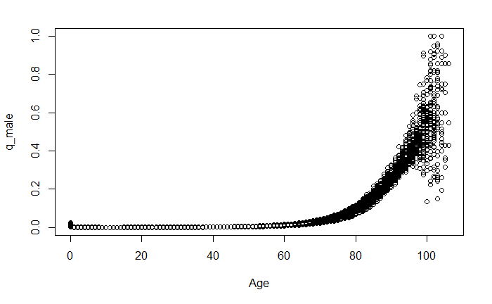

```r
with(df,{
    plot(Age,q_male)
  }
) #1.2.1
```

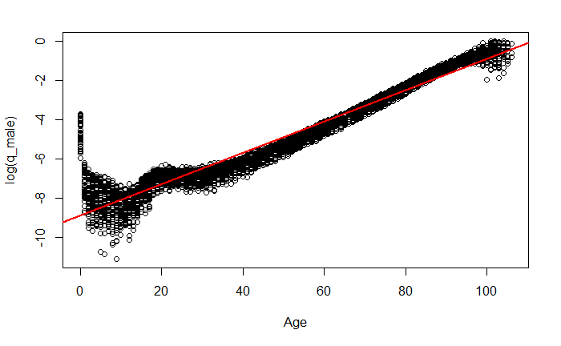

```r
with(df,{
    plot(Age,log(q_male))
    abline(lm(log(q_male)~Age),col="red",lwd=2)
  }
) #1.2.1
```

1.2.1 结论：年龄与男性死亡率成对数关系

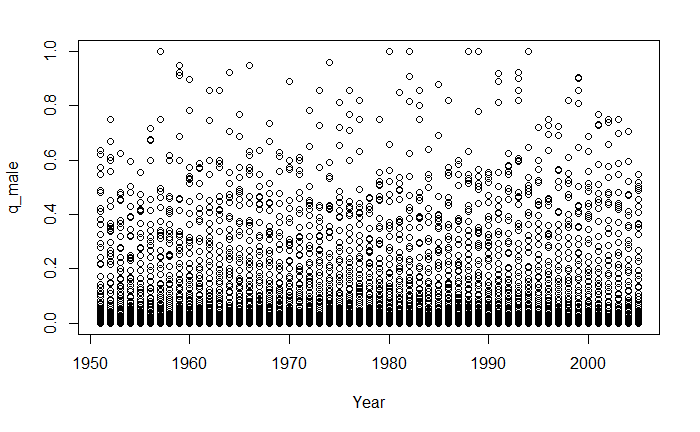

```r
with(df,{
    plot(Year,q_male)
  }
) #1.2.2
```

### 1.3

##### 1.3.1 绘制年龄与对数生存人数的散点图，分析这2个量的关系。

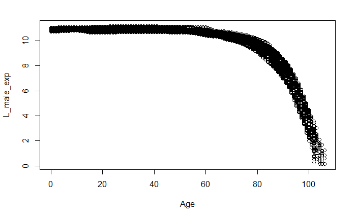

```r
with(df,{
    plot(Age,L_male_exp)
  }
) #1.3.1
```

### 1.4

##### 1.4.1 绘制直方图来观察一下男性死亡人数的分布

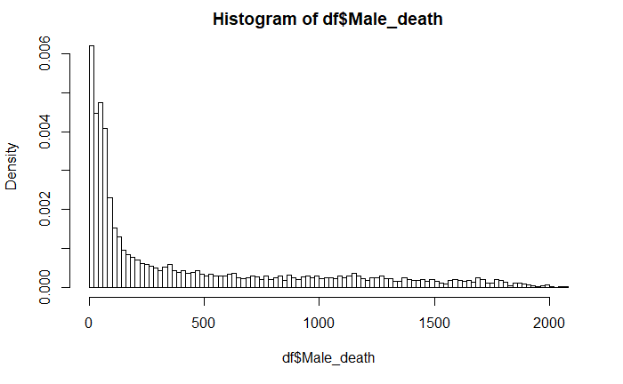

```r
hist(df$Male_death,freq = FALSE,breaks = 100) #1.4.1
```

### 1.5

##### 1.5.1 绘制男性的对数死亡人数的直方图，来观察男性的对数死亡人口数的分布情况。

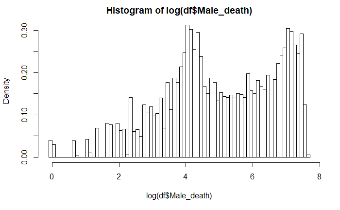

```r
hist(log(df$Male_death),freq = FALSE,breaks = 100) #1.5.1
```

### 1.6

##### 1.6.1 计算df的各变量的相关系数

##### 1.6.2 画出相关图

```r
cor(df) #1.6.1
```

```
                     Year         Age Female_Exp    Male_Exp    q_female       q_male Female_death  Male_death L_female_exp  L_male_exp
Year          1.000000000  0.02179254  0.1160631  0.09147251 -0.01478749  0.005604303   0.08110344  0.05365316   0.07237373  0.03282184
Age           0.021792540  1.00000000 -0.8309089 -0.87070172  0.69132612  0.708193461   0.58868207  0.52346090  -0.68294215 -0.71423462
Female_Exp    0.116063146 -0.83090887  1.0000000  0.98895478 -0.83273201 -0.839917409  -0.47321416 -0.29265898   0.83556867  0.85676881
Male_Exp      0.091472511 -0.87070172  0.9889548  1.00000000 -0.78337569 -0.797285400  -0.57866606 -0.42116000   0.78279870  0.81039904
q_female     -0.014787485  0.69132612 -0.8327320 -0.78337569  1.00000000  0.945039489   0.09918616 -0.05621058  -0.96587548 -0.97215569
q_male        0.005604303  0.70819346 -0.8399174 -0.79728540  0.94503949  1.000000000   0.14631933 -0.01164316  -0.94865226 -0.96077107
Female_death  0.081103438  0.58868207 -0.4732142 -0.57866606  0.09918616  0.146319332   1.00000000  0.91431144  -0.05506756 -0.11027227
Male_death    0.053653157  0.52346090 -0.2926590 -0.42116000 -0.05621058 -0.011643158   0.91431144  1.00000000   0.07731497  0.03461496
L_female_exp  0.072373732 -0.68294215  0.8355687  0.78279870 -0.96587548 -0.948652265  -0.05506756  0.07731497   1.00000000  0.99517189
L_male_exp    0.032821843 -0.71423462  0.8567688  0.81039904 -0.97215569 -0.960771072  -0.11027227  0.03461496   0.99517189  1.00000000
```

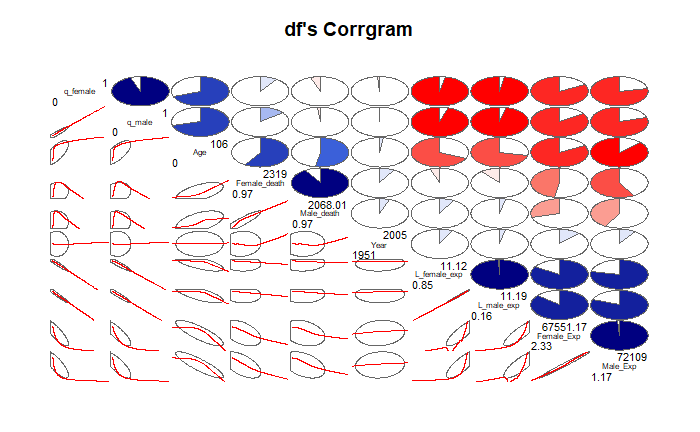

```r
#install.packages("corrgram")
#library(corrgram)
corrgram(df, order=TRUE, main="df's Corrgram",
  lower.panel=corrgram::panel.ellipse,
  upper.panel=panel.pie, diag.panel=panel.minmax
) #1.6.2
```

# 数据2介绍

选取堪培拉房价交易指数数据，仅通过该数据进行一些可视化分析，数据显示如下表

| 变量名称 | 描述 |  |
| --- | --- | --- |
| date | 日期 |  |
| index | 房价指数（HPI） |  |
| year | 年 |  |
| month | 月 |  |

# 题目2

**注：增长量，可以用下一条减上一条来计算；第一条的上一条的HPI值可以认为是1**

### 2.1

##### 2.1.1 通过读取文件House-handle.csv获取数据保存到houseIndex中

```r
houseIndex <- read.csv("House-handle.csv") #2.1.1
houseIndex
```

| date | index | year | month |
| --- | --- | --- | --- |
| 28-Feb-90 | 1.01469 | 1990 | 2 |
| 31-Mar-90 | 1.02241 | 1990 | 3 |
| 30-Apr-90 | 1.03062 | 1990 | 4 |
| 31-May-90 | 1.03903 | 1990 | 5 |
| 30-Jun-90 | 1.04729 | 1990 | 6 |
| 31-Jul-90 | 1.05276 | 1990 | 7 |
| 31-Aug-90 | 1.05833 | 1990 | 8 |
| 30-Sep-90 | 1.06390 | 1990 | 9 |
| 31-Oct-90 | 1.06977 | 1990 | 10 |
| 30-Nov-90 | 1.07594 | 1990 | 11 |

[output cut: 242 more lines]

### 2.2

##### 2.2.1 数据探索，绘制一张图表来展示1990到2011年的HPI的变化情况，横轴是时间 （可以是数据的第一列），纵轴是HPI值。

```r
Sys.setlocale("LC_TIME","us")
```

```
[1] "English_United States.1252"
```

```r
houseIndex <- within(houseIndex,{
    .date <- as.Date(date,"%d-%b-%y")
  }
)
Sys.setlocale("LC_TIME","")
```

```
[1] "Chinese (Simplified)_China.936"
```

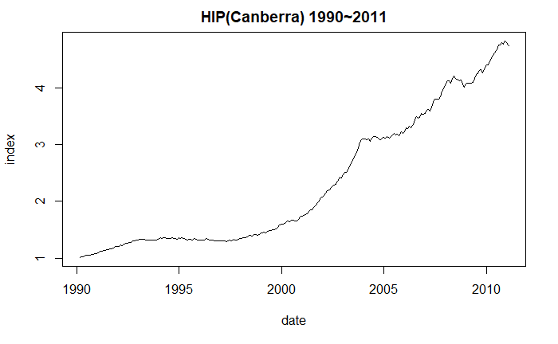

```r
with(houseIndex,{
    subIndex <- houseIndex[1990<=year&year<=2011,]
    plot(subIndex$.date,subIndex$index,type="l",xlab="date",ylab="index",main="HIP(Canberra) 1990~2011")
  }
) #2.2.1
```

### 2.3

##### 2.3.1 绘制一张图，展示每个月的HPI的增长量，表示为delta,在0的位置添加参考线。

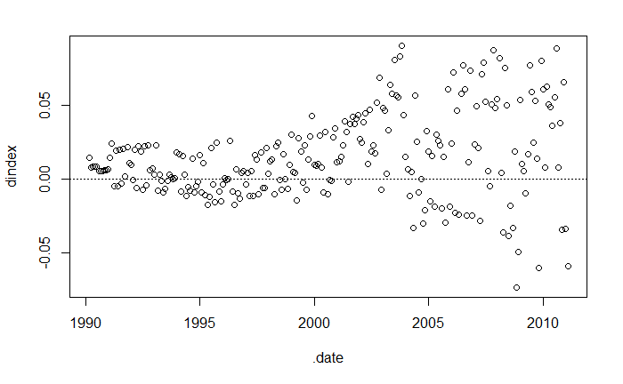

```r
houseIndex <- within(houseIndex[order(houseIndex$.date),],{
    dindex <- index-c(1,index[-nrow(houseIndex)])
    plot(.date,dindex)
    abline(h=0,lty="dotted")
  }
) #2.3.1
```

### 2.4

##### 2.4.1 为了进一步了解HPI的波动，计算其每个月的增长率。绘图时，增长率为正数的 月份由加号（“+”）表示，为负的用（“o”）表示。

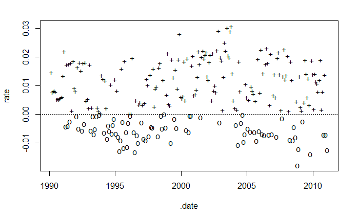

```r
houseIndex <- within(houseIndex,{
    rate <- dindex/(index-dindex)
    plot(.date,rate,
      pch=ifelse(0<rate,"+",ifelse(rate<0,"o","-"))
    )
    abline(h=0,lty="dotted")
  }
) #2.4.1
```

### 2.5

##### 2.5.1 对HPI增长率建立表格，其中每一行代表一个月份，每一列代表一个年份，显示前四年的数据（ HPI增长率舍入到小数点后4位）

##### 2.5.2 绘制一个HPI的平均年增长率

##### 2.5.3 绘制一个HPI的平均月增长率（全部年份的年增长率（列平均）和月增长率（行平均））

```r
contingencyTable <- xtabs(rate~month+year,data=houseIndex)
round(contingencyTable[,1:4],4) #2.5.1
```

```
     year
month    1990    1991    1992    1993
   1   0.0000  0.0134 -0.0007  0.0172
   2   0.0147  0.0219  0.0164 -0.0057
   3   0.0076 -0.0043 -0.0050  0.0023
   4   0.0080  0.0174  0.0180 -0.0007
   5   0.0082 -0.0041  0.0151 -0.0069
   6   0.0079  0.0176 -0.0057 -0.0051
   7   0.0052 -0.0025  0.0178 -0.0008
   8   0.0053  0.0179 -0.0034  0.0023
   9   0.0053  0.0013  0.0180  0.0010
   10  0.0055  0.0186  0.0046 -0.0001
   11  0.0058  0.0091  0.0055  0.0004
   12  0.0061  0.0081  0.0021  0.0136
```

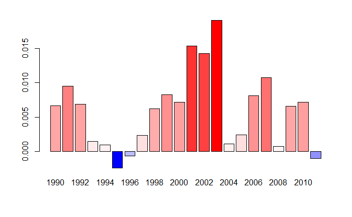

```r
colorfulBarplot <- function(ct){
  minct <- min(ct)
  maxct <- max(ct)
  cs <- ifelse(ct > 0,ct/maxct,ct/minct)
  barplot(ct,
    col=ifelse(ct > 0,rgb(1, 1-cs, 1-cs),rgb(1-cs, 1-cs, 1))
  )
}
colorfulBarplot(colMeans(contingencyTable)) #2.5.2
```

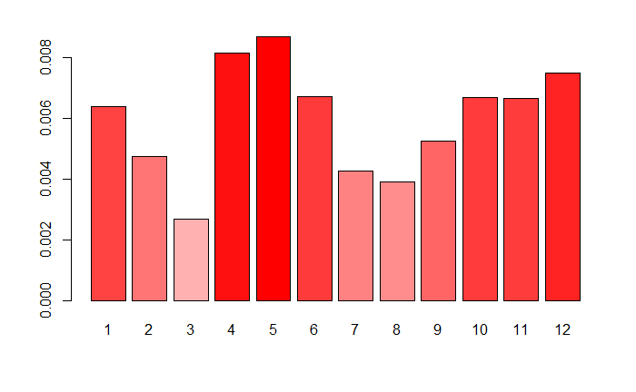

```r
colorfulBarplot(rowMeans(contingencyTable)) #2.5.3
```

```r
rm(colorfulBarplot)
```

### 2.6

##### 2.6.1 绘制一个箱线图，来查看HPI的增长率的分布情况。

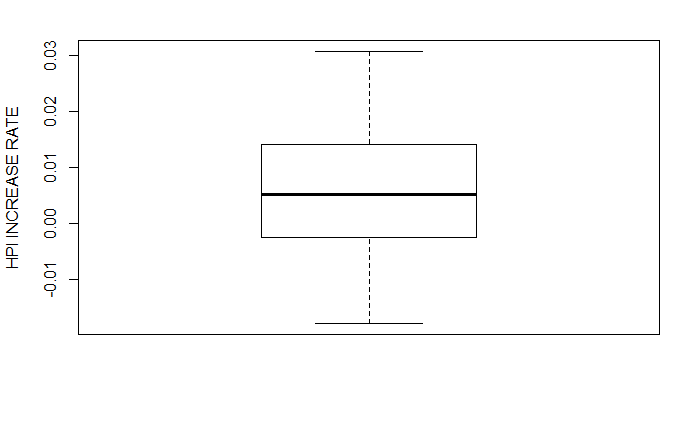

```r
boxplot(contingencyTable,ylab="HPI INCREASE RATE") #2.6.1
```

```r
rm(contingencyTable)
```